# Speeding up R for Calculating Euclidean Distances

Gibril

# Introduction

The task is to calculate euclidean distances between rows in a matrix. It is divided into two subproblems, one with groups and without groups. The following `R` packages have been used:

- `Rcpp`
- `microbenchmark`: for timings

A base `R` function was used as a benchmark for the timings. Three `C` source codes were used which were sourced into `R` via it’s `C` API and a `C++` script via `Rcpp` library.

| Function | Language |
| --- | --- |
| naive_dist | `R` |
| dot_dist | `R` |
| fastdist2 | `C++` |
| eucDist | `C` & `R` |
| r_euc_dist | `C` & `R` |
| cDist | `C` & `R` |

# Timings : Ungrouped

Below are sample outputs from the functions for a matrix with 2000 entries for the ungrouped problem and relative timings of each of the functions for different matrix sizes. All timings were in milliseconds.

```
Unit: milliseconds
          expr        min         lq       mean     median         uq
 naive_dist(M) 115.139840 120.060930 130.419957 125.704581 132.208132
       dist(M)   2.432668   3.308361   6.356756   3.926424   5.074132
 r_euc_dist(M)   2.616436   3.330798   7.379464   3.833894   4.486725
   dot_dist(M) 673.753718 723.242430 768.162506 753.764015 796.262480
  fastdist2(M)  10.874602  12.146634  17.410744  13.472862  15.964630
    eucDist(M)   2.605100   3.456320   6.764453   3.846511   4.416576
      cDist(M)   1.877975   2.455699   6.573165   3.195958   3.880205
        max neval
  197.57561   100
   55.02963   100
   52.26835   100
 1017.22427   100
   59.76397   100
   52.69272   100
   54.42619   100
```

```
[1] "naive_dist"
```

```
[1]  8.104245 20.166204 24.063068 14.315379 28.043333 11.600828
```

```
[1] "dist"
```

```
[1]  8.104245 20.166204 24.063068 14.315379 28.043333 11.600828
```

```
[1] "r_euc_dist"
```

```
[1]  8.104245 20.166204 24.063068 14.315379 28.043333 11.600828
```

```
[1] "dot_dist"
```

```
[1]  8.104245 20.166204 24.063068 14.315379 28.043333 11.600828
```

```
[1] "fastdist2"
```

```
[1]  8.104245 20.166204 24.063068 14.315379 28.043333 11.600828
```

```
[1] "eucDist"
```

```
[1]  8.104245 20.166204 24.063068 14.315379 28.043333 11.600828
```

```
[1] "cDist"
```

```
[1]  8.104245 20.166204 24.063068 14.315379 28.043333 11.600828
```

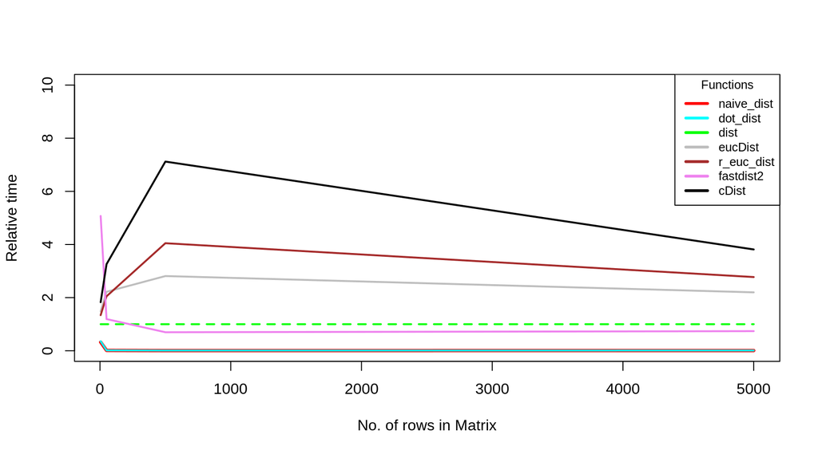

# Timings: Grouped

## Output

Below are sample outputs from the functions `dist`, `cDist`, `naive_dist`, `r_euc_dist` and `eucDist` for the grouped problem. The outputs from all the functions are the same so only one is shown. The functions `dot_dist` and `fastdist2` could not be modified to allow for a vectorised calculation of distances within each group.

```
INDICES: 1
  [1] 17.953014 29.055633 20.280481 36.992981 30.461330 13.499654 25.497846
  [8] 23.251852  6.954638 16.455878 25.955105 25.275923 31.722903  4.423357
 [15] 28.973370 10.539937 11.934160 18.790168 21.836891 27.875367 22.281440
 [22] 21.972519 11.312633 12.047727 21.163439 12.516000 28.284468 17.196294
 [29] 17.983686 17.824807 24.551286 16.328599 11.391780 23.801526 15.540253
 [36] 11.791640 27.457483 29.623682 16.318462 14.364219 42.274637  4.641332
 [43]  5.686311 19.321377 11.759840  3.663682 39.515878 22.332847 20.439148
 [50] 29.064728 34.947336 20.782440 14.123785 27.434811 26.137581  2.586903
 [57] 37.957892 40.858410 21.349812 21.089434 53.301610  8.157001  7.588540
 [64] 30.933881 18.090438 24.649020  5.776565 29.720994 15.778034 17.257108
 [71]  5.756167  7.004466 12.595475 20.521479 21.068989 30.803808 29.225970
 [78] 27.347882  2.349000 36.501819 11.637599 17.158372 14.240403 48.986535
 [85] 34.087414 20.143698 38.627851 45.686806 32.519508 25.860807 38.994485
 [92] 33.242297  9.876369 44.173504 48.891321 23.299129 32.791032 63.246715
```

[output cut: 1641 more lines]

## Relative times

The graph below shows the relative timings of each of the functions for different matrix sizes. All timings are in milliseconds.

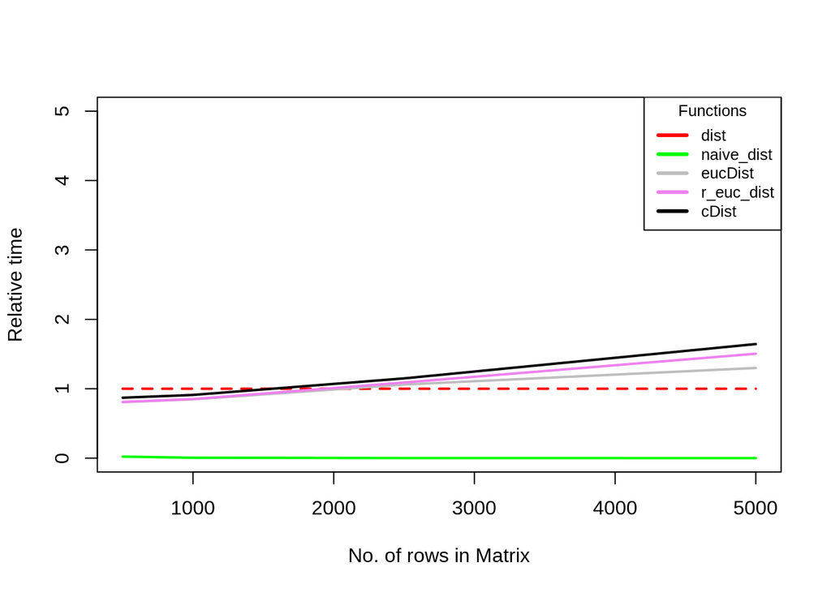

# Functions

The function `naive_dist()` is written purely in R using the formula `dist = sqrt((xi-xj)^2 + (yi-yj)^2)`, `dist()` is the base `R` implementation, `dot_dist()` is also written purely R but uses the dot product method of calculating distances, `fastdist2()` is a `C++` implementation of the calculation and `r_euc_dist()`, `eucDist()` and `cDist` are `R` wrapper functions for `C` implementaions of the calculation.

`naive_dist()`

```
naive_dist <- function(x){

#TODO: function documentation

    result = vector('numeric', length = nrow(x) * (nrow(x) - 1)/2)
    k = 1
    for (i in 1:(nrow(x)-1)){
        for (j in (i+1):nrow(x)){
          result[k] = sqrt((x[i,1]-x[j,1])^2 + (x[i,2] - x[j,2])^2)
          k = k + 1
        }
    }
    result
}
```

`dot_dist()`

```
dot_dist <- function(x){
# TODO: function documentation
  result = vector('numeric', length = nrow(x) * (nrow(x) - 1)/2)

  i = 1
  m = 1
  while (i <= (nrow(x)-1)){
    for (j in (i+1):nrow(x)){
      k         = x[i,] - x[j,]
      result[m] = sqrt(k %*% k)
      m         = m + 1
    }
    i = i + 1
  }
  result
}
```

`fastdist2()`

```
// filename: fastdist2.cpp

#include <Rcpp.h>
using namespace Rcpp;

//[[Rcpp::export]]

NumericVector fastdist2 (const NumericMatrix &x){
    unsigned int outrows = x.nrow(), i = 0, j = 0, k = 0;

    Rcpp::NumericVector out(outrows * (outrows - 1)/2);

    for (i = 0; i <= outrows - 2; i++){
        for (j = i+1; j <= outrows - 1; j++){

            out(k) = sqrt(sum(pow(x.row(i) - x.row(j), 2.0)));
                    k++;
}
    }
    return out;
}
```

`r_euc_dist() and euc_dist()`

```
# filename: r_euc_dist.R
# last edited: 7-AUG-2019


r_euc_dist <- function(matrix, cols_interest = 1:2){

# R wrapper function for euc_dist.c
# check euc_dist.c for source code and function documentation
# input:
#       matrix: an N by 2 numeric matrix
#       cols_interest : if input is a data.frame, the cols to be used.

# output: a vector of euclidean distances between rows
    cpMat   = matrix[, cols_interest]
    len_mat = dim(cpMat)[1] * dim(cpMat)[2]
    n_rows  = nrow(cpMat)
    vec     = as.vector(t(cpMat))

    .C("euc_dist",
        as.double(vec),
        as.integer(len_mat),
        as.double(vector("double", n_rows * (n_rows - 1)/2)))[[3]]

    }

/*
filename: euc_dist.c
last edited: 23-JUL-2019
*/


#include <R.h>
#include <math.h>

/*
Calculates the euclidean distance between rows of a matrix

input:
    vec: a one dimensional array of length N * 2 where N is the number of rows
       in the input matrix.
    len_vec: N * 2
output:
    result: a one dimensional array of length N * 2 containing the calculated distances
*/

void euc_dist(double *vec, int *len_vec, double *result)
{
    int k = 0, i, j, iter1 = *len_vec - 3, iter2 = *len_vec - 1;

    for (i = 0; i < iter1; i += 2){
        for (j = i + 2; j < iter2; j += 2){
            result[k] = sqrt((vec[i] - vec[j]) * (vec[i] - vec[j])
                        + (vec[i+1] - vec[j+1]) * (vec[i+1] - vec[j+1]));
            k++;
        }
      }

}
```

`eucDist() and eucDist()`

```
# filename: eucDist.R
# wrapper function for eucDist.c
# TODO: error correcting code

eucDist <- function(matrix, cols_interest = 1:2){

    cpMat   = matrix[, cols_interest]
    len_mat = dim(matrix)[1] * dim(matrix)[2]
    n_rows  = nrow(matrix)
    n_cols  = ncol(matrix)
    vec     = as.vector(t(matrix))


    .C('eucDist',
       as.double(vec),
       as.integer(n_rows),
       as.integer(n_cols),
       as.double(vector("double", n_rows * (n_rows - 1)/2))
       )[[4]]
}

#include <math.h>
#include <R.h>
#include <Rinternals.h>

/* Euclidean distance */
/*q=.C("eucdist",as.integer(c(1,2,3,4,5,6,7,8)),as.integer(4),as.integer(2),as.double(vector("double",6))*/
void eucDist(double *x, int *m, int *n, double *d)
{
  /* Arguement:
    1.  x is a matrix of dimension n by m
    2.  m is the number of rows
    3.  n is the number of coloums
    4.  d is the pointer for output */
  /*
   d = sqrt(sum((XI-XJ).^2,2));            % Euclidean
   */
  int i,j,k; /* **pointer; /* Indexers */
  int local_m, local_n;
  local_m = *m, local_n = *n;
```

[output cut: 21 more lines]

```
      // XI = XI0; /* Index? */
      theSum = 0.0;
      for (k=0;k<local_n;k++,++XI,++XJ){
        theSum += pow((x[XI]- x[XJ]), 2.0);
        // Rprintf("x[XI] is %lf and x[XJ] is %lf\n", x[XI], x[XJ]);
        // Rprintf("The sum is %lf\n", theSum);
        // Rprintf("The sum is %d\n", theSum);
      }
      XI = XI0;
      d[index++] = sqrt(theSum);
      // Rprintf("d is %lf\n", d[index]);
      // XI = XI0; /* Index? */
    }
  }
}
```

`cDist() and cDist()`

```
/*
filename: cDist.c
last edited: 24-JUL-19
*/


/*
 exactly as euc_dist.c but modified to use R's .Call() interface

 input:
    Rvec: a one-dimensional array of length N * 2 where N is the number of rows
          in the input matrix.

    resLen: an integer (coerced to double) of the number of pairs
            calculated as N * (N - 1)/2.
 output:
    result: a one-dimensional array containing the calculated distances.
*/

#include <R.h>
#include <Rinternals.h>
#include <math.h>

SEXP cDist(SEXP Rvec, SEXP resLen){
    int k = 0, i, j, iter1 = length(Rvec) - 3, iter2 = length(Rvec) - 1;

    SEXP result = PROTECT(allocVector(REALSXP, asReal(resLen)));
    double *vec = REAL(Rvec);

    for(i = 0; i < iter1; i += 2){
        for(j = i + 2; j < iter2; j += 2){
            REAL(result)[k] = sqrt(((vec[i] - vec[j]) * (vec[i] - vec[j])) +
                         ((vec[i+1] - vec[j+1]) * (vec[i+1] - vec[j+1])));
            k++;
        }
    }

    UNPROTECT(1);
    return result;

```

[output cut: 12 more lines]

```
#
# output: a vector of euclidean distances between the rows of the matrix.
# TODO: error-correcting code



cDist <- function(matrix, cols_interest = 1:2){
    cpMat  = matrix[, cols_interest]
    vec    = as.vector(t(cpMat))
    reslen = nrow(cpMat) * (nrow(cpMat) - 1) * 0.5

    .Call("cDist",
           as.double(vec),
           as.double(reslen))
}
```